# Ambulance Wait Time Analysis - R Tutorial

A Step-by-Step Guide for R Beginners

Blake Demarest

August 27, 2025

# Introduction

This tutorial will walk you through a hypothesis test analysis in R, explaining each function and concept along the way. We’ll analyze ambulance response times to determine if a company meets compliance standards.

## The Problem

An ambulance company is being evaluated for compliance. The legal requirement states that the average response time should not exceed 10 minutes. A judge ordered 300 records to be examined.

**Our Hypothesis Test:**

- **Null Hypothesis ($H_0$):** $\mu \leq 10$ minutes (Company is compliant)
- **Alternative Hypothesis ($H_a$):** $\mu > 10$ minutes (Company is non-compliant)
- **Significance Level:** $\alpha = 0.05$ (5% chance of Type I error)

# Step 1: Setting Up Your Workspace

```r
# rm() function: "remove" - clears objects from memory
# list = ls() means "list all objects"
# This gives us a clean slate to start
rm(list = ls())

# Note: In R, the hashtag (#) creates a comment
# Comments are notes for humans and are ignored by R
```

## What These Functions Do:

- **`rm()`**: Removes objects from your R environment
- **`ls()`**: Lists all objects currently in memory
- **`rm(list = ls())`**: Combining these clears everything - like clearing your desk before starting new work

# Step 2: Loading the Data

```r
# read.csv() reads a CSV (Comma-Separated Values) file into R
# It creates a "data frame" - R's version of a spreadsheet/table
waittime_data <- read.csv("waittime.csv")

# The arrow <- is the assignment operator
# It means "put the result into this variable"
# We could also use = but <- is more traditional in R
```

## Understanding the Assignment Operator

In R, we store values in variables using `<-` or `=`:

```r
# Examples of assignment:
my_number <- 42
my_name <- "Student"
my_calculation <- 10 + 5

# We can then use these variables:
cat("My number is:", my_number, "\n")
```

```
## My number is: 42
```

```r
cat("My name is:", my_name, "\n")
```

```
## My name is: Student
```

```r
cat("My calculation result is:", my_calculation, "\n")
```

```
## My calculation result is: 15
```

# Step 3: Exploring Your Data

Before analyzing, always explore your data first!

```r
# str() shows the "structure" of your data
# It tells you the type of object and its contents
str(waittime_data)
```

```
## 'data.frame':    300 obs. of  2 variables:
##  $ X: int  1 2 3 4 5 6 7 8 9 10 ...
##  $ x: num  14.48 12.51 8.66 4.58 7.65 ...
```

```r
# head() shows the first 6 rows (the "head" of the data)
# This gives you a preview of what your data looks like
head(waittime_data)
```

```
##   X         x
## 1 1 14.477130
## 2 2 12.514725
## 3 3  8.663849
## 4 4  4.580644
## 5 5  7.649425
## 6 6 14.169064
```

```r
# summary() provides statistical summaries for each column
# For numbers: min, max, mean, median, quartiles
summary(waittime_data)
```

```
##        X                x
##  Min.   :  1.00   Min.   : 2.400
##  1st Qu.: 75.75   1st Qu.: 8.371
##  Median :150.50   Median :10.281
##  Mean   :150.50   Mean   :10.311
##  3rd Qu.:225.25   3rd Qu.:12.375
##  Max.   :300.00   Max.   :19.872
```

```r
# nrow() counts the number of rows (observations)
n <- nrow(waittime_data)
cat("Sample size:", n, "\n")
```

```
## Sample size: 300
```

## What We Learned About Our Data:

- We have 300 observations (rows)
- Two columns: `X` (row numbers) and `x` (wait times in minutes)
- Wait times range from 2.4 to 19.9 minutes
- The median wait time is 10.28 minutes

# Step 4: Extracting and Analyzing the Wait Times

```r
# The dollar sign $ extracts a column from a data frame
# dataframe$columnname gives you that column as a vector
wait_times <- waittime_data$x

# mean() calculates the average
mean_wait <- mean(wait_times, na.rm = TRUE)

# sd() calculates standard deviation (spread of data)
sd_wait <- sd(wait_times, na.rm = TRUE)

# sqrt() calculates square root
# Standard error = standard deviation / square root of n
se_wait <- sd_wait / sqrt(n)

# cat() prints output without quotes or brackets
cat("\nDescriptive Statistics:\n")
```

```
##
## Descriptive Statistics:
```

```r
cat("Mean wait time:", round(mean_wait, 2), "minutes\n")
```

```
## Mean wait time: 10.31 minutes
```

```r
cat("Standard deviation:", round(sd_wait, 2), "minutes\n")
```

```
## Standard deviation: 3.12 minutes
```

```r
cat("Standard error:", round(se_wait, 3), "minutes\n")
```

```
## Standard error: 0.18 minutes
```

## Understanding These Statistics:

- **Mean (Average)**: Add all values and divide by count. Our mean is 10.31 minutes.
- **Standard Deviation**: Measures how spread out the data is. Ours is 3.12 minutes.
- **Standard Error**: Measures uncertainty in our mean estimate. Smaller is better!

### The `na.rm = TRUE` Parameter

- **NA** stands for “Not Available” (missing data)
- **na.rm = TRUE** means “remove NAs before calculating”
- This prevents errors if your data has missing values

# Step 5: Visualizing the Data

A picture is worth a thousand numbers!

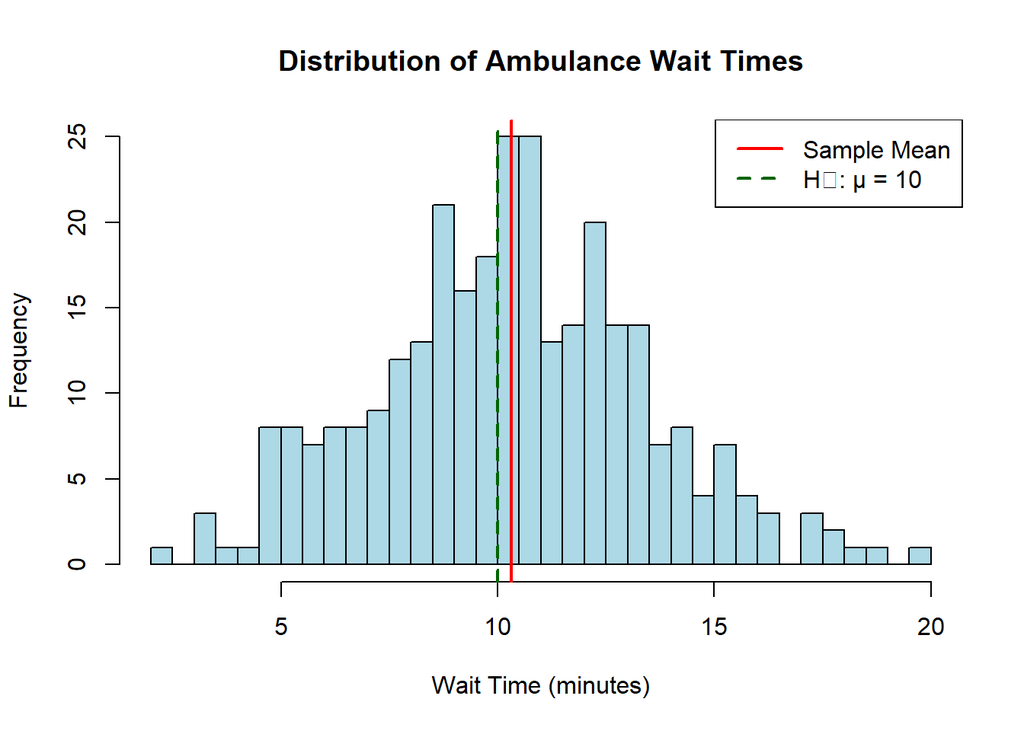

```r
# hist() creates a histogram (frequency bar chart)
hist(wait_times,
     main = "Distribution of Ambulance Wait Times",  # Title
     xlab = "Wait Time (minutes)",                    # X-axis label
     col = "lightblue",                              # Bar color
     breaks = 30)                                     # Number of bins

# abline() adds straight lines to the plot
# v = vertical line at specified x-value
abline(v = mean_wait, col = "red", lwd = 2)
abline(v = 10, col = "darkgreen", lwd = 2, lty = 2)

# legend() adds a legend explaining the lines
legend("topright",                                    # Position
       legend = c("Sample Mean", "H₀: μ = 10"),      # Labels
       col = c("red", "darkgreen"),                  # Colors
       lty = c(1, 2),                                # Line types
       lwd = 2)                                       # Line width
```

## What the Histogram Shows:

- The distribution is roughly bell-shaped (approximately normal)
- Most wait times are between 7-13 minutes
- The red line (sample mean) is slightly to the right of the green line (10 minutes)
- This visual suggests the mean might be above 10, but is it statistically significant?

# Step 6: The Hypothesis Test

Now for the main analysis - testing if the mean significantly exceeds 10 minutes.

```r
# Set our significance level (alpha)
# This is our tolerance for making a Type I error (false positive)
mu_0 <- 10      # The value we're testing against
alpha <- 0.05   # 5% significance level

# t.test() performs a t-test
# We use this when we don't know the population standard deviation
t_test <- t.test(wait_times,               # The data to test
                 mu = mu_0,                 # Test if mean equals this
                 alternative = "greater",   # We only care if it's greater
                 conf.level = 1 - alpha)    # Confidence level (95%)

# Extract and display results
cat("\nHYPOTHESIS TEST RESULTS\n")
```

```
##
## HYPOTHESIS TEST RESULTS
```

```r
cat("========================================\n")
cat("Test Statistic (t):", round(t_test$statistic, 3), "\n")
```

```
## Test Statistic (t): 1.726
```

```r
cat("Degrees of freedom:", t_test$parameter, "\n")
```

```
## Degrees of freedom: 299
```

```r
cat("P-value:", round(t_test$p.value, 4), "\n")
```

```
## P-value: 0.0427
```

## Understanding the t-test Parameters:

- **`mu`**: The value we’re comparing our mean against (10 minutes)
- **`alternative = "greater"`**: We’re doing a one-tailed test (only testing if mean > 10)
  - Use `"two.sided"` to test if mean ≠ 10
  - Use `"less"` to test if mean < 10
- **`conf.level`**: The confidence level (1 - α = 0.95 means 95% confidence)

## Understanding the Output:

- **Test Statistic (t = 1.726)**: Measures how many standard errors our mean is from 10
- **Degrees of freedom (299)**: n - 1, used to determine the exact t-distribution
- **P-value (0.0427)**: The probability of seeing data this extreme if H₀ were true

# Step 7: Making a Decision

```r
# Use an if-else statement to make our decision
if (t_test$p.value < alpha) {
  cat("\n*** DECISION: REJECT H₀ ***\n")
  cat("The p-value (", round(t_test$p.value, 4), ") is less than α (", alpha, ")\n", sep="")
  cat("\nConclusion: The ambulance company is NON-COMPLIANT.\n")
  cat("There is statistically significant evidence that the average\n")
  cat("wait time exceeds 10 minutes.\n")
} else {
  cat("\n*** DECISION: FAIL TO REJECT H₀ ***\n")
  cat("The p-value (", round(t_test$p.value, 4), ") is greater than α (", alpha, ")\n", sep="")
  cat("\nConclusion: Insufficient evidence of non-compliance.\n")
}
```

```
##
## *** DECISION: REJECT H₀ ***
## The p-value (0.0427) is less than α (0.05)
##
## Conclusion: The ambulance company is NON-COMPLIANT.
## There is statistically significant evidence that the average
## wait time exceeds 10 minutes.
```

## The Decision Rule:

- If **p-value < α**: Reject H₀ (evidence supports H_a)
- If **p-value ≥ α**: Fail to reject H₀ (insufficient evidence)

In our case: p-value (0.0427) < α (0.05), so we **REJECT H₀**

# Final Interpretation

## Statistical Conclusion

With a p-value of 0.0427, we have statistically significant evidence at the 5% level that the ambulance company’s average response time exceeds 10 minutes. The company is **NON-COMPLIANT** based on this criterion.

## Practical Significance

```r
# Let's look at the practical implications
excess_time <- mean_wait - 10
percent_over <- (mean_wait - 10) / 10 * 100

cat("The average wait time is", round(excess_time, 2), "minutes over the limit.\n")
```

```
## The average wait time is 0.31 minutes over the limit.
```

```r
cat("This represents a", round(percent_over, 1), "% increase over the standard.\n")
```

```
## This represents a 3.1 % increase over the standard.
```

While statistically significant, the practical impact is relatively small:

- The mean is only 0.31 minutes (about 19 seconds) over the limit
- This is a 3.1% increase over the 10-minute standard

## Recommendations

1. **For the Company**: While violating the standard, the violation is marginal. Small operational improvements could bring them into compliance.
2. **For the Court**: The evidence shows non-compliance, but the severity is minimal. Consider whether this small difference has practical impact on patient outcomes.
3. **Statistical Note**: With large samples (n=300), even small differences can be statistically significant. Always consider both statistical AND practical significance.

# R Function Reference Guide

Here’s a quick reference of all functions we used:

| Function | Purpose | Example |
| --- | --- | --- |
| `rm()` | Remove objects from memory | `rm(list = ls())` |
| `ls()` | List all objects in memory | `ls()` |
| `read.csv()` | Read CSV file | `data <- read.csv("file.csv")` |
| `str()` | Show structure of object | `str(data)` |
| `head()` | Show first 6 rows | `head(data)` |
| `summary()` | Statistical summary | `summary(data)` |
| `nrow()` | Count rows | `n <- nrow(data)` |
| `mean()` | Calculate average | `mean(x, na.rm = TRUE)` |
| `sd()` | Standard deviation | `sd(x, na.rm = TRUE)` |
| `sqrt()` | Square root | `sqrt(16)` returns 4 |
| `round()` | Round numbers | `round(3.14159, 2)` returns 3.14 |
| `cat()` | Print output | `cat("Hello", "World\n")` |
| `hist()` | Create histogram | `hist(data)` |
| `abline()` | Add lines to plot | `abline(v = 10, col = "red")` |
| `legend()` | Add legend to plot | `legend("topright", ...)` |
| `t.test()` | Perform t-test | `t.test(x, mu = 10)` |
| `if/else` | Conditional logic | `if (condition) {do this} else {do that}` |

# Practice Exercises

Try these exercises to reinforce your learning:

## Exercise 1: Change the Hypothesis

```r
# What if the standard was 12 minutes instead of 10?
# Run a t-test with mu = 12
# What's your conclusion now?
```

## Exercise 2: Two-Tailed Test

```r
# Run a two-tailed test (alternative = "two.sided")
# How does this change your p-value?
# Would you still reject H₀?
```

## Exercise 3: Explore the Data

```r
# Calculate the median wait time
# What percentage of calls exceed 10 minutes?
# Hint: Use median() and mean(wait_times > 10)
```

# Summary

You’ve learned how to:

1. ✅ Load and explore data in R
2. ✅ Calculate descriptive statistics
3. ✅ Create visualizations
4. ✅ Perform hypothesis tests
5. ✅ Interpret statistical results
6. ✅ Make data-driven decisions

Remember: Statistics is about making informed decisions under uncertainty. Our test provided evidence, not absolute proof. Always consider both statistical significance and practical importance!